# Carbon Fibre Data

## Introduction

Its sampling is equally divided between its predictors as it consists into 30 observations: 10 for each of the 3 additives, 15 for each temperature level. Below, on Table 1, you can see the first rows of the data:

Table 1: Fist lines of Carbon Fibre Dataset

| X | additive | temperature | strength |
| --- | --- | --- | --- |
| 1 | a | Low | 76 |
| 2 | a | Low | 90 |
| 3 | a | Low | 89 |
| 4 | a | Low | 105 |
| 5 | a | Low | 89 |
| 6 | a | High | 74 |

The objective here is identify the relationship between those two predictors and strenght. Let’s first start with a Main Effects Model to understand the relationship between those predictors and the response:

## Model 1: Main Effects Model

Our Main Effects Model is the following:
$$y_i = \beta_0 + \beta_1 \delta_{i,b} + \beta_2 \delta_{i,c} + \beta_3 \gamma_{i,low} + \varepsilon_i$$
Where $\delta_{i,b}$ will be 1 in case of using additive b, or zero otherwise, same for $\delta_{i,c}$ for additive c. If both $\delta$ are zero, then additive a is being used.
Also $\gamma_{i,low}$ will be 1 in case a low temperature was used, otherwise, it will be 0. We can start accessing the relevance of this model by checking if any of the predictors have an effect on strength.
$H_0: \beta_1=\beta_2=\beta_3=0$

$H_\alpha: \beta_j\neq0$ for some j $\epsilon${1,2,3}

Table 2: Anovatab for Main Effects Model

|  | df | Sum Sq | Mean Sq | F value | Pr(>F) |
| --- | --- | --- | --- | --- | --- |
| Model | 3 | 8267.500 | 2755.8333 | 8.161278 | 0.0005418 |
| Error | 26 | 8779.467 | 337.6718 | NA | NA |
| Total | 29 | 17046.967 | NA | NA | NA |

Based on the anovatab above, with p-value 0.0005418, we reject $H_0$ and conclude that at least one predictor affects strength.  
We can also check the coeficcients of the model and see if they are significant:

Table 3: Coeficients for Main Effects Model

|  | Estimate | Std. Error | t value | Pr(>\|t\|) |
| --- | --- | --- | --- | --- |
| (Intercept) | 103.46667 | 6.709911 | 15.419976 | 0.0000000 |
| additiveb | -17.60000 | 8.217929 | -2.141659 | 0.0417614 |
| additivec | -22.20000 | 8.217929 | -2.701411 | 0.0119911 |
| temperatureLow | -27.13333 | 6.709911 | -4.043769 | 0.0004170 |

Based on the P values we can see that all predictors are significant on the current model and they all reduce the strength. An important detail is that this model assumes that temperature and additive don’t iteract with each other. To consider that, we need to move to an Iteration model.

## Model 2, Iteraction Model

Our new model with iteration terms is the following:
$$y_i = \beta_0 + \beta_1 \delta_{i,b} + \beta_2 \delta_{i,c} + \beta_3 \gamma_{i,low} + \beta_4 \delta_{i,b} \gamma_{i,low} + \beta_5 \delta_{i,c} \gamma_{i,low} + \varepsilon_i$$

Where this part $\beta_4 \delta_{i,b} \gamma_{i,low} + \beta_5 \delta_{i,c} \gamma_{i,low}$ is the iteration part of the model.

```
## Single term deletions
##
## Model:
## strength ~ additive + temperature + additive:temperature
##                      Df Sum of Sq    RSS    AIC F value   Pr(>F)
## <none>                            5386.4 167.71
## additive:temperature  2    3393.1 8779.5 178.37  7.5592 0.002844 **
## ---
## Signif. codes:  0 '***' 0.001 '**' 0.01 '*' 0.05 '.' 0.1 ' ' 1
```

In this new model, we can see that the iteraction `additive:temperature` is significant (p-value 0.002844). Although we can see on the coefficients became somewhat problematic with $\beta_1,\beta_2,\beta_3$ with p-values > 0.05.

Table 4: Coeficients for Iteraction Model

|  | Estimate | Std. Error | t value | Pr(>\|t\|) |
| --- | --- | --- | --- | --- |
| (Intercept) | 90.0 | 6.699751 | 13.4333346 | 0.0000000 |
| additiveb | 8.4 | 9.474879 | 0.8865549 | 0.3841164 |
| additivec | -7.8 | 9.474879 | -0.8232295 | 0.4184829 |
| temperatureLow | -0.2 | 9.474879 | -0.0211084 | 0.9833337 |
| additiveb:temperatureLow | -52.0 | 13.399503 | -3.8807411 | 0.0007118 |
| additivec:temperatureLow | -28.8 | 13.399503 | -2.1493335 | 0.0419023 |

As the iteraction part works and its predictors are significantly higher in value, let’s ignore for now the problematic $\beta_1,\beta_2,\beta_3$ and see a plot of this model.

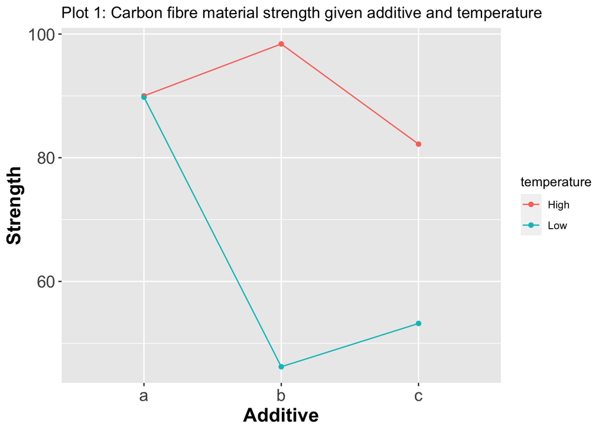

Here we can see that additive a has nearly identical good performance in high or low temperatures, whereas additive b has the best performance of them all in a high temperature and the worst performance in a low temperature. We can also see that additive c performs badly on low temperature and better on high temperature but not with extreme difference as additive b.

Table 5: Pairwise Contrasts for Iteraction Model

| contrast | estimate | SE | df | t.ratio | p.value |
| --- | --- | --- | --- | --- | --- |
| a High - b High | -8.4 | 9.474879 | 24 | -0.8865549 | 0.4965626 |
| a High - c High | 7.8 | 9.474879 | 24 | 0.8232295 | 0.4965626 |
| a High - a Low | 0.2 | 9.474879 | 24 | 0.0211084 | 0.9833337 |
| a High - b Low | 43.8 | 9.474879 | 24 | 4.6227503 | 0.0004288 |
| a High - c Low | 36.8 | 9.474879 | 24 | 3.8839546 | 0.0018616 |
| b High - c High | 16.2 | 9.474879 | 24 | 1.7097844 | 0.1670098 |
| b High - a Low | 8.6 | 9.474879 | 24 | 0.9076633 | 0.4965626 |
| b High - b Low | 52.2 | 9.474879 | 24 | 5.5093051 | 0.0001728 |
| b High - c Low | 45.2 | 9.474879 | 24 | 4.7705094 | 0.0004288 |
| c High - a Low | -7.6 | 9.474879 | 24 | -0.8021211 | 0.4965626 |
| c High - b Low | 36.0 | 9.474879 | 24 | 3.7995208 | 0.0018709 |
| c High - c Low | 29.0 | 9.474879 | 24 | 3.0607251 | 0.0100680 |
| a Low - b Low | 43.6 | 9.474879 | 24 | 4.6016418 | 0.0004288 |
| a Low - c Low | 36.6 | 9.474879 | 24 | 3.8628461 | 0.0018616 |
| b Low - c Low | -7.0 | 9.474879 | 24 | -0.7387957 | 0.5005664 |

On the pairwise contrast table we can see the statistic significance between different temperatures and additives. As seen in the chart, there is no difference between additive a with high or low temperatures.  
Also, most importantly to notice, there is no difference in strength between additive b with high temperature and additive a (either with high or low temperature), both pairs have a very high p-value of 0.496. In fact, there is not even evidence that b at high temperature is better than c at a high temperature (p-value 0.167)

Table 6: Pairwise 95% CI for Iteraction Model

| additive | temperature | emmean | SE | df | lower.CL | upper.CL |
| --- | --- | --- | --- | --- | --- | --- |
| a | High | 90.0 | 6.699751 | 24 | 76.17239 | 103.82761 |
| b | High | 98.4 | 6.699751 | 24 | 84.57239 | 112.22761 |
| c | High | 82.2 | 6.699751 | 24 | 68.37239 | 96.02761 |
| a | Low | 89.8 | 6.699751 | 24 | 75.97239 | 103.62761 |
| b | Low | 46.2 | 6.699751 | 24 | 32.37239 | 60.02761 |
| c | Low | 53.2 | 6.699751 | 24 | 39.37239 | 67.02761 |

We can also confirm looking at the 95% CI of each of each predictor combination how additive has almost identical confidence intervals for high and low temperature and how much a(high and low), b(high) and c(high) overlap on its confidence intervals.

## Conclusion

We’ve concluded with our interaction model that all additives a, b, and c are equally good on high temperature. Additive a though, seems to perform also as good as the others in low temperature. There is big evidence also that additive b and c perform poorly in creating carbon fibre material strength in low temperatures

## R Code:

```r
# setwd as the folder where this script is in
current_path = rstudioapi::getActiveDocumentContext()$path
setwd(dirname(current_path))
```

```r
# Setup that will be used across the rest of this notebook:
#Install and load kable extra to render tables in a nicer way
#install.packages("kableExtra")
library(kableExtra)
#install and load tidyverse to do dataset manipulations
#install.packages("tidyverse")
library(tidyverse)
source("anovatab.R")
# set a seed to gel always the same "random" results
set.seed(29011987)

# read carbonfibre cvs into a a dataframe
carbon_fibre <- read.csv("carbon_fibre.csv", header=T)
# summary of dataset just to see what is in the data:
summary(carbon_fibre)
```

```r
head(carbon_fibre) %>%
  kbl(caption = "Table 1: Fist lines of Carbon Fibre Dataset") %>%
  kable_styling()
```

```r
# Transform categorical variables into factor in the dataset
carbon_fibre$additive <- factor(carbon_fibre$additive)
carbon_fibre$temperature <- factor(carbon_fibre$temperature)
# Fit main effect model
fit1=lm(strength~additive+temperature, data = carbon_fibre)
anovaTab1 <- anovatab(fit1)
```

```r
anovaTab1 %>%
  kbl(caption = "Table 2: Anovatab for Main Effects Model") %>%
  kable_styling()
```

```r
summary(fit1)[["coefficients"]] %>%
  kbl(caption = "Table 3: Coeficients for Main Effects Model") %>%
  kable_styling()
```

```r
# Add iteration to the model
fit2=update(fit1,.~.+additive:temperature)
drop1(fit2,test='F')
```

```r
summary(fit2)[["coefficients"]] %>%
  kbl(caption = "Table 4: Coeficients for Iteraction Model") %>%
  kable_styling()
```

```r
library(emmeans);library(ggplot2)

g=emmip(fit2,temperature ~ additive)
g+theme(axis.text=element_text(size=14),
        axis.title=element_text(size=16,face="bold"))+
ylab("Strength")+
  xlab ('Additive')+
  labs(title="Plot 1: Carbon fibre material strength given additive and temperature")
```

```r
emmeansFit2 <- emmeans(fit2,pairwise~additive:temperature,adjust='fdr')
emmeansFit2$contrasts %>%
kbl(caption = "Table 5: Pairwise Contrasts for Iteraction Model") %>%
  kable_styling()
```

```r
emmeansFit2$emmeans %>%
kbl(caption = "Table 6: Pairwise 95% CI for Iteraction Model") %>%
  kable_styling()
```